# **MPDW PRAKTIKUM P3**

Joshua Bryan Wijaya_G1401231082

2025-09-15

# **LIBRARY**

```r
library(dLagM)
library(dynlm)
library(MLmetrics)
library(lmtest)
library(car)
library(dplyr)
```

```r
library(readxl)
library(ggplot2)
```

# **DATA**

```r
data <- read.csv("C:/Users/Dell/OneDrive/Desktop/SEMESTER 5/MPDW/Pertemuan 3/NewDelhi_Air_quality.csv")
data
```

```
##     X  AQI       CO      datetime        no2       o3      pm10     pm25
## 1   0 30.2 198.6027 2022-10-21:18 0.04685717 55.78995 10.486722 5.637410
## 2   1 28.2 197.6013 2022-10-21:19 0.04645554 54.93164 10.719325 4.618169
## 3   2 26.6 198.6027 2022-10-21:20 0.04685717 54.64554 11.155578 3.520902
## 4   3 25.0 201.9405 2022-10-21:21 0.04819594 55.07469 11.116206 2.225919
## 5   4 26.0 205.2784 2022-10-21:22 0.04886533 55.78995 10.405250 1.979471
## 6   5 26.0 208.6163 2022-10-21:23 0.05020411 56.50520  9.402518 1.792677
## 7   6 26.0 208.6163 2022-10-22:00 0.05020411 55.78995  8.482822 1.752237
## 8   7 24.0 205.2784 2022-10-22:01 0.05020411 52.92892  7.586667 1.858459
## 9   8 23.0 200.2716 2022-10-22:02 0.04685717 50.06790  7.636587 2.208076
## 10  9 24.0 196.9338 2022-10-22:03 0.04417961 51.49841  8.487648 2.476681
## 11 10 25.0 198.6027 2022-10-22:04 0.04284084 53.64418  9.357371 2.585729
## 12 11 26.0 200.2716 2022-10-22:05 0.04049798 55.78995 10.338728 2.390081
## 13 12 27.0 203.6095 2022-10-22:06 0.04016329 59.36623 10.523314 2.086022
## 14 13 29.0 205.2784 2022-10-22:07 0.03882451 62.22725 10.635970 1.937047
```

[output cut: 131 more lines]

# **EKSPLORASI DATA**

```r
summary(data)
```

```
##        X              AQI              CO          datetime
##  Min.   : 0.00   Min.   :19.00   Min.   :191.9   Length:72
##  1st Qu.:17.75   1st Qu.:25.00   1st Qu.:197.4   Class :character
##  Median :35.50   Median :27.00   Median :200.3   Mode  :character
##  Mean   :35.50   Mean   :26.18   Mean   :200.1
##  3rd Qu.:53.25   3rd Qu.:28.00   3rd Qu.:203.6
##  Max.   :71.00   Max.   :32.00   Max.   :208.6
##       no2                o3             pm10             pm25
##  Min.   :0.01556   Min.   :41.48   Min.   : 6.687   Min.   :1.633
##  1st Qu.:0.03799   1st Qu.:53.64   1st Qu.: 7.865   1st Qu.:1.829
##  Median :0.04552   Median :57.22   Median : 8.914   Median :2.202
##  Mean   :0.04200   Mean   :56.57   Mean   : 9.115   Mean   :2.295
##  3rd Qu.:0.05020   3rd Qu.:60.08   3rd Qu.:10.275   3rd Qu.:2.522
##  Max.   :0.06091   Max.   :68.66   Max.   :12.846   Max.   :5.637
##       so2         timestamp_local    timestamp_utc            ts
##  Min.   :0.2831   Length:72          Length:72          Min.   :1.666e+09
##  1st Qu.:0.3204   Class :character   Class :character   1st Qu.:1.666e+09
##  Median :0.3725   Mode  :character   Mode  :character   Median :1.667e+09
##  Mean   :0.3634                                         Mean   :1.667e+09
##  3rd Qu.:0.3958                                         3rd Qu.:1.667e+09
##  Max.   :0.4545                                         Max.   :1.667e+09
```

```r
colSums(is.na(data))
```

```
##               X             AQI              CO        datetime             no2
##               0               0               0               0               0
##              o3            pm10            pm25             so2 timestamp_local
##               0               0               0               0               0
##   timestamp_utc              ts
##               0               0
```

```r
data[!complete.cases(data), ]
```

```
##  [1] X               AQI             CO              datetime
##  [5] no2             o3              pm10            pm25
##  [9] so2             timestamp_local timestamp_utc   ts
## <0 rows> (or 0-length row.names)
```

Data **Kualitas Udara New Delhi** merupakan data deret waktu untuk kualitas udara di New Delhi yang tercatat untuk 72 periode waktu, mulai dari 21 Oktober 2022 hingga 24 Oktober 2022. Tiap observasi dicatat dalam selang 1 jam, sehingga 72 periode waktu berarti ada 72 jam amatan untuk kualitas udara. Data tidak memiliki data null dan tidak memiliki record waktu yang hilang. Selain itu, tipe data untuk setiap peubah pada data sudah sesuai.

# **SPLIT DATA**

```r
train<-data[1:58,]
test<-data[59:72,]
train.ts<-ts(train)
test.ts<-ts(test)
data.ts<-ts(data)
```

Data **Kualitas Udara New Delhi** kemudian dibagi menjadi data uji dan data latih. Perbandingan yang digunakan adalah 80:20, sehingga data latih berjumlah 58 observasi dan data uji berjumlah 14 observasi.

# **VISUALISASI**

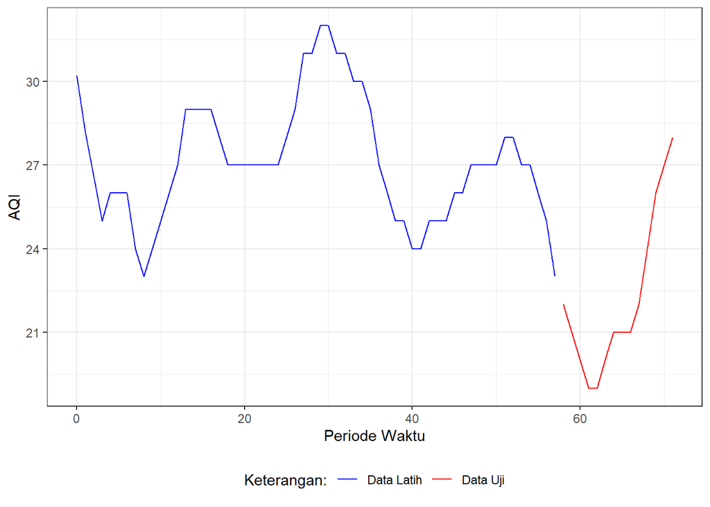

```r
ggplot() +
  geom_line(data = train, aes(x = X, y = AQI, col = "Data Latih")) +
  geom_line(data = test, aes(x = X, y = AQI, col = "Data Uji")) +
  labs(x = "Periode Waktu", y = "AQI", color = "Legend") +
   scale_colour_manual(name="Keterangan:", breaks = c("Data Latih", "Data Uji"),
                      values = c("blue", "red")) +
  theme_bw() + theme(legend.position = "bottom",
                     plot.caption = element_text(hjust=0.5, size=12))
```

# **MODEL KOYCK**

```r
model.koyck <- koyckDlm(x = train$o3, y = train$AQI)
summary(model.koyck)
```

```
##
## Call:
## "Y ~ (Intercept) + Y.1 + X.t"
##
## Residuals:
##       Min        1Q    Median        3Q       Max
## -1.112282 -0.366467 -0.002877  0.258311  1.106529
##
## Coefficients:
##             Estimate Std. Error t value Pr(>|t|)
## (Intercept)  0.26260    0.93950   0.280    0.781
## Y.1          0.42943    0.08641   4.969 7.14e-06 ***
## X.t          0.25823    0.04259   6.064 1.35e-07 ***
## ---
## Signif. codes:  0 '***' 0.001 '**' 0.01 '*' 0.05 '.' 0.1 ' ' 1
##
## Residual standard error: 0.5239 on 54 degrees of freedom
## Multiple R-Squared: 0.9449,  Adjusted R-squared: 0.9429
## Wald test: 417.1 on 2 and 54 DF,  p-value: < 2.2e-16
##
## Diagnostic tests:
## NULL
##
##                             alpha      beta       phi
## Geometric coefficients:  0.460243 0.2582336 0.4294305
```

```r
AIC(model.koyck)
```

```
## [1] 92.98106
```

```r
BIC(model.koyck)
```

```
## [1] 101.1533
```

Dari hasil tersebut, didapat bahwa peubah $x_t$ dan $y_{t-1}$ memiliki nilai $P - Value < 0.05$. Hal ini menunjukkan bahwa peubah $x_t$ dan $y_{t-1}$ berpengaruh signifikan terhadap $y$. Adapun model keseluruhannya adalah sebagai berikut

$$Y_t = 0.2626 + 0.2582X_t +
0.4294Y_{t-1}$$

Model Koyck merupakan salah satu pendekatan dari model Distributed Lag, dimana Y akan didefinisikan dengan peubah X pada lag tertentu, tapi tidak dengan diri Y sendiri. Alasan kenapa peubah $y_{t-1}$ muncul dalam persamaan adalah karena penurunan persamaan akibat penurunan koefisien secara konstan pada model Koyck. Penurunan rumus ini menyebabkan persamaan model Koyck yang awalnya berupa:
$$y_t= \alpha + \beta_0
X_t + \beta_0 CX_{t-1} + \beta_0 C^2 X_{t-2}$$
akan dilakukan penurunan rumus hingga menjadi:
$$y_t= \alpha
(1-C) + \beta_0 X_t + CY_{t-1} + V_t$$
Oleh sebab itulah muncul $y_{t-1}$ dalam model

## Peramalan

```r
fore.koyck <- forecast(model = model.koyck, x=test$o3, h=14)
fore.koyck
```

```
## $forecasts
##  [1] 22.51461 21.65971 20.92318 20.05278 19.58666 19.84824 20.51469 20.80088
##  [9] 20.92378 21.43831 22.95219 24.71052 26.20441 27.21533
##
## $call
## forecast.koyckDlm(model = model.koyck, x = test$o3, h = 14)
##
## attr(,"class")
## [1] "forecast.koyckDlm" "dLagM"
```

Distributed Lag Model (DLM) dapat didekati dengan menggunakan persamaan koyck. Nilai Y pada data test akan diprediksi menggunakan persamaan dari model koyck, dengan input x pada data test. Forecast akan dilakukan untuk 14 observasi pada data uji.

## Akurasi

```r
mape.koyck <- MAPE(fore.koyck$forecasts, test$AQI)
mape.koyck
```

```
## [1] 0.02909543
```

```r
GoF(model.koyck)
```

```
##              n     MAE           MPE       MAPE      sMAPE      MASE      MSE
## model.koyck 57 0.39765 -0.0005611615 0.01494044 0.01491151 0.5986129 0.260024
##                  MRAE    GMRAE
## model.koyck 545222624 5097.033
```

Untuk mengukur performa model Koyck, dihitung nilai MAPE dengan membandingkan nilai y hasil prediksi dengan nilai y aktual yang ada pada data test. Nilai MAPE yang diperoleh untuk hasil peramalan pada data uji adalah 0.029 atau setara dengan 2.9%. Selain itu, menggunakan fungsi **GoF**, diperoleh nilai MAPE 0.015, atau setara 1.5%. Artinya, Nilai MAPE untuk prediksi data latih maupun peramalan data uji memiliki MAPE < 10%, sehingga dapat dikatakan, persamaan Koyck yang diperoleh dari data latih sudah cukup baik dalam prediksi serta tidak mengalami overfitting

# **REGRESSION WITH DISTRIBUTED LAG**

## Menentukan lag optimum

```r
finiteDLMauto(formula = AQI ~ o3,
              data = data.frame(train), q.min = 1, q.max = 10,
              model.type = "dlm", error.type = "AIC", trace = TRUE)
```

```
##    q - k    MASE      AIC      BIC     GMRAE   MBRAE R.Adj.Sq  Ljung-Box
## 10    10 0.33647 24.10757 48.43318 10779.390 0.48008  0.98393 0.41122212
## 5      5 0.36542 27.02479 42.78712  6410.480 0.48192  0.98352 0.18919655
## 3      3 0.38312 27.10177 39.14577  5879.350 0.48128  0.98290 0.11147130
## 4      4 0.38276 27.96420 41.88709  7635.896 0.48443  0.98283 0.17399541
## 6      6 0.36302 29.64290 47.20409  4742.320 0.47166  0.98307 0.19759073
## 9      9 0.36482 30.09649 52.79833  8867.244 0.48588  0.98222 0.76300049
## 7      7 0.37392 30.57737 49.89563  5848.238 0.47755  0.98314 0.27764544
## 8      8 0.38196 31.33341 52.36567  8039.153 0.49778  0.98265 0.41731544
## 2      2 0.41082 47.04815 57.17490  5489.740 0.47425  0.97492 0.08786534
## 1      1 0.48746 91.76306 99.93527  5751.269 0.38586  0.94411 0.16242279
```

Berdasarkan output diatas, **lag = 10** merupakan lag optimum bagi data. Hal ini dikarenakan nilai AIC-nya paling kecil (**AIC = 24.11**) dan $\adj.R^2$-nya paling tinggi, yaitu 0.98. Selanjutnya akan dilakukan pemodelan dengan lag=10

```r
model.dlm <- dlm(x = train$o3,y = train$AQI , q = 10)
summary(model.dlm)
```

```
##
## Call:
## lm(formula = model.formula, data = design)
##
## Residuals:
##      Min       1Q   Median       3Q      Max
## -0.48304 -0.17355  0.04636  0.17934  0.52554
##
## Coefficients:
##             Estimate Std. Error t value Pr(>|t|)
## (Intercept) -0.64267    0.89957  -0.714  0.47958
## x.t          0.42814    0.06180   6.928 4.08e-08 ***
## x.1          0.13889    0.13339   1.041  0.30473
## x.2         -0.05734    0.12788  -0.448  0.65654
## x.3         -0.14994    0.12237  -1.225  0.22840
## x.4          0.15911    0.12493   1.274  0.21095
## x.5         -0.01335    0.12436  -0.107  0.91510
## x.6         -0.12709    0.12430  -1.022  0.31338
## x.7          0.27371    0.12253   2.234  0.03180 *
## x.8         -0.37459    0.12097  -3.097  0.00378 **
## x.9          0.28924    0.10409   2.779  0.00862 **
## x.10        -0.09537    0.04837  -1.971  0.05640 .
## ---
## Signif. codes:  0 '***' 0.001 '**' 0.01 '*' 0.05 '.' 0.1 ' ' 1
##
## Residual standard error: 0.2739 on 36 degrees of freedom
## Multiple R-squared:  0.9877, Adjusted R-squared:  0.9839
## F-statistic: 262.6 on 11 and 36 DF,  p-value: < 2.2e-16
##
## AIC and BIC values for the model:
##        AIC      BIC
## 1 24.10757 48.43318
```

Setelah diperoleh bahwa lag optimum X untuk peramalan Y adalah 10, maka dilakukan pemodelan DLM menggunakan lag = 10. Dari hasil tersebut, didapat bahwa peubah $x_t$, $x_{t-7}$, $x_{t-8}$, dan $x_{t-9}$ memiliki nilai $P - Value < 0.05$. Hal ini menunjukkan bahwa peubah $x_t$, $x_{t-7}$, $x_{t-8}$, dan $x_{t-9}$ berpengaruh signifikan terhadap $Y_t$. Adapun model keseluruhannya adalah sebagai berikut

$$Y_t = -0.6427 + 0.4281X_t +
0.1389x_{t-1} - 0.0573x_{t-2} - 0.1499x_{t-3} + 0.1591x_{t-4} -
0.0134x_{t-5} - 0.1271x_{t-6} + 0.2737x_{t-7} - 0.3746x_{t-8} +
0.2892x_{t-9} - 0.0954x_{t-10}$$

```r
AIC(model.dlm)
```

```
## [1] 24.10757
```

```r
BIC(model.dlm)
```

```
## [1] 48.43318
```

Sebelumnya kan model DLM didekati dengan persamaan koyck. Tapi disini dengan pemodelan DLM langsung, hasil akhir modelnya sudah sesuai dengan model yang diperkenalkan pada DLM, yakni $Y_t$ didefinisikan oleh lag peubah X.
$$y_t= \alpha + \beta_0 X_t + \beta_0
CX_{t-1} + \beta_0 C^2 X_{t-2}$$

## Peramalan

```r
fore.dlm <- forecast(model = model.dlm, x=test$o3, h=14)
fore.dlm
```

```
## $forecasts
##  [1] 21.71254 20.68921 20.02702 19.13710 18.76899 19.53092 20.95694 21.06735
##  [9] 20.45470 21.52028 23.77255 26.47778 27.61003 27.92625
##
## $call
## forecast.dlm(model = model.dlm, x = test$o3, h = 14)
##
## attr(,"class")
## [1] "forecast.dlm" "dLagM"
```

Nilai Y pada data test akan diprediksi menggunakan persamaan dari model DLM, dengan input x pada data test. Forecast akan dilakukan untuk 14 observasi pada data uji.

## Akurasi

```r
mape.dlm<- MAPE(fore.dlm$forecasts, test$AQI)
mape.dlm
```

```
## [1] 0.0127254
```

```r
GoF(model.dlm)
```

```
##            n       MAE           MPE        MAPE       sMAPE     MASE
## model.dlm 48 0.2004478 -7.414126e-05 0.007373085 0.007368538 0.336466
##                  MSE      MRAE    GMRAE
## model.dlm 0.05628638 896417348 10779.39
```

Untuk mengukur performa model DLM, dihitung nilai MAPE dengan membandingkan nilai y hasil prediksi dengan nilai y aktual yang ada pada data test. Nilai MAPE yang diperoleh untuk hasil peramalan pada data uji adalah 0.0127 atau setara dengan 1.27%. Selain itu, menggunakan fungsi **GoF**, diperoleh nilai MAPE 0.0074, atau setara 0.74%. Artinya, Nilai MAPE untuk prediksi data latih maupun peramalan data uji memiliki MAPE < 10%, sehingga dapat dikatakan, persamaan DLM yang diperoleh dari data latih sudah cukup baik dalam prediksi serta tidak mengalami overfitting

# **MODEL AUTOREGRESSIVE**

## Mencari Lag Optimum

```r
model.ardl.opt <- ardlBoundOrders(data = data.frame(train), ic = "AIC",
                                  formula = AQI ~ o3)
model.ardl.opt
```

```
## $p
##   o3
## 1 15
##
## $q
## [1] 15
##
## $Stat.table
##           q = 1    q = 2    q = 3    q = 4    q = 5    q = 6    q = 7    q = 8
## p = 1  41.56280 27.20590 29.12810 31.53440 32.03393 32.29336 34.53155 36.14709
## p = 2  26.87609 28.86655 31.11933 33.13405 33.38586 32.71763 35.00443 36.76036
## p = 3  31.28652 31.28652 33.10852 35.13347 35.37808 32.42665 35.04175 36.88102
## p = 4  31.13666 32.63009 32.63009 31.56697 34.34268 34.38881 36.52186 38.63527
## p = 5  32.30514 33.38040 34.39026 34.39026 36.11274 36.26853 38.50587 40.35697
## p = 6  33.96399 35.37809 34.63661 36.48492 36.48492 38.26097 40.15853 42.33776
## p = 7  35.94634 36.93272 36.16825 37.34035 38.72243 38.72243 37.13284 34.18672
## p = 8  30.21149 31.74840 32.83849 34.10006 34.46802 36.36771 36.36771 35.84426
## p = 9  28.54117 30.40438 30.67552 32.65040 33.30928 34.95583 36.73594 36.73594
## p = 10 30.77825 32.66266 32.21807 34.18451 33.73414 35.49864 37.42995 38.91235
## p = 11 29.15902 29.32776 30.13522 32.03167 31.94475 33.85113 35.17956 37.15495
## p = 12 30.39260 30.95289 31.29008 33.28787 33.59730 35.57543 35.83313 37.56054
## p = 13 17.42541 15.95397 17.57598 15.16006 12.32802 13.52369 12.78361 14.62617
## p = 14 19.54670 18.45002 20.41148 21.41963 17.20507 19.20464 16.69725 18.68926
## p = 15 21.07316 18.97198 20.96140 20.18938 18.09546 19.00916 18.79506 20.23456
##           q = 9   q = 10   q = 11     q = 12    q = 13     q = 14     q = 15
## p = 1  37.23638 37.26685 38.53736 38.9524180  40.93474  34.719816  23.665775
## p = 2  38.38011 39.24668 39.94465 40.3125231  42.39639  36.661408  25.563294
## p = 3  37.44398 38.37978 40.39183 40.7697684  41.59464  36.032476  24.767367
## p = 4  39.35622 40.34878 42.36177 42.7687274  43.06963  36.981658  24.925693
## p = 5  41.01121 41.87869 43.78360 44.6095624  45.06853  38.804453  26.884769
## p = 6  41.42694 42.35028 43.53013 44.8981831  46.53109  37.020658  22.227271
## p = 7  36.76947 39.13235 41.20796 42.9180618  44.20760  29.898156  15.715040
## p = 8  36.53784 39.17714 37.08263 38.4616360  38.98098  29.081981  17.651688
## p = 9  37.99740 41.06310 37.37522 37.6320163  37.30255  23.971734   3.524722
## p = 10 38.91235 40.13740 33.35975 34.8479419  35.08619  22.778694   4.747989
## p = 11 34.01516 34.01516 34.28093 36.8475066  36.74395  23.042633   5.753838
## p = 12 35.21946 37.21927 37.21927 38.8470499  33.08442   9.458672 -10.390026
## p = 13 12.47203 13.74791 10.42502 10.4250227  11.41350   8.628001  -8.552976
## p = 14 17.66444 19.51492 20.60963 -8.0120602  -8.01206  -7.952746  -8.461879
## p = 15 14.79711 13.06089 12.41000 -0.2564838 -10.60372 -10.603717  -9.048415
##
## $min.Stat
## [1] -10.60372
```

```r
min_p=c()
for(i in 1:6){
  min_p[i]=min(model.ardl.opt$Stat.table[[i]])
}
q_opt=which(min_p==min(min_p, na.rm = TRUE))
p_opt=which(model.ardl.opt$Stat.table[[q_opt]] ==
              min(model.ardl.opt$Stat.table[[q_opt]], na.rm = TRUE))
data.frame("q_optimum" = q_opt, "p_optimum" = p_opt,
           "AIC"=model.ardl.opt$min.Stat)
```

```
##   q_optimum p_optimum       AIC
## 1         5        13 -10.60372
```

```r
model.ardl <- ardlDlm(formula = AQI ~ o3,
                         data = train,p = 13 , q = 5)
summary(model.ardl)
```

```
##
## Time series regression with "ts" data:
## Start = 14, End = 58
##
## Call:
## dynlm(formula = as.formula(model.text), data = data)
##
## Residuals:
##      Min       1Q   Median       3Q      Max
## -0.41712 -0.18376  0.03146  0.18776  0.45616
##
## Coefficients:
##              Estimate Std. Error t value Pr(>|t|)
## (Intercept) -1.028150   1.117030  -0.920    0.366
## o3.t         0.425234   0.086646   4.908 4.73e-05 ***
## o3.1         0.207160   0.233381   0.888    0.383
## o3.2        -0.161809   0.235813  -0.686    0.499
## o3.3         0.008421   0.254870   0.033    0.974
## o3.4         0.177362   0.211227   0.840    0.409
## o3.5         0.029689   0.186863   0.159    0.875
## o3.6        -0.188494   0.148792  -1.267    0.217
## o3.7         0.251685   0.154640   1.628    0.116
## o3.8        -0.251076   0.154426  -1.626    0.117
## o3.9         0.099657   0.163219   0.611    0.547
## o3.10        0.167947   0.170091   0.987    0.333
## o3.11       -0.245884   0.177620  -1.384    0.178
## o3.12        0.084848   0.156626   0.542    0.593
## o3.13        0.011899   0.067647   0.176    0.862
## AQI.1       -0.118458   0.211476  -0.560    0.580
## AQI.2        0.121349   0.200355   0.606    0.550
## AQI.3       -0.190481   0.244677  -0.778    0.444
## AQI.4       -0.144694   0.215205  -0.672    0.508
## AQI.5        0.031315   0.206713   0.151    0.881
## ---
## Signif. codes:  0 '***' 0.001 '**' 0.01 '*' 0.05 '.' 0.1 ' ' 1
##
## Residual standard error: 0.2952 on 25 degrees of freedom
## Multiple R-squared:  0.9897, Adjusted R-squared:  0.9819
## F-statistic: 126.3 on 19 and 25 DF,  p-value: < 2.2e-16
```

```r
AIC(model.ardl)
```

```
## [1] 33.43188
```

```r
BIC(model.ardl)
```

```
## [1] 71.37179
```

$$Y_t = -1.0282 + 0.4252X_t +
0.2072X_{t-1} - 0.1618X_{t-2} + 0.0084X_{t-3} + 0.1774X_{t-4} +
0.0297X_{t-5} - 0.1885X_{t-6} + 0.2517X_{t-7} - 0.2511X_{t-8} +
0.0997X_{t-9} + 0.1679X_{t-10} - 0.2459X_{t-11} + 0.0848X_{t-12} +
0.0119X_{t-13} - 0.1185Y_{t-1} + 0.1213Y_{t-2} - 0.1905Y_{t-3} -
0.1447Y_{t-4} + 0.0313Y_{t-5}$$

## Peramalan

```r
fore.ardl <- forecast(model = model.ardl, x=test$o3, h=14)
fore.ardl
```

```
## $forecasts
##  [1] 21.87654 20.65286 20.12724 19.18800 18.74105 19.60551 20.93937 21.05950
##  [9] 20.42200 21.56473 23.87246 26.43475 27.61168 27.82457
##
## $call
## forecast.ardlDlm(model = model.ardl, x = test$o3, h = 14)
##
## attr(,"class")
## [1] "forecast.ardlDlm" "dLagM"
```

Nilai Y pada data test akan diprediksi menggunakan persamaan dari model ARDL, dengan input x pada data test. Forecast akan dilakukan untuk 14 observasi pada data uji.

## Akurasi

```r
mape.ardl <- MAPE(fore.ardl$forecasts, test$AQI)
mape.ardl
```

```
## [1] 0.01255268
```

```r
GoF(model.ardl)
```

```
##             n       MAE           MPE        MAPE       sMAPE      MASE
## model.ardl 45 0.1903753 -6.803415e-05 0.006984351 0.006982044 0.3490214
##                   MSE      MRAE   GMRAE
## model.ardl 0.04839882 909636206 22957.7
```

Untuk mengukur performa model ARDL, dihitung nilai MAPE dengan membandingkan nilai y hasil prediksi dengan nilai y aktual yang ada pada data test. Nilai MAPE yang diperoleh untuk hasil peramalan pada data uji adalah 0.0125 atau setara dengan 1.25%. Selain itu, menggunakan fungsi **GoF**, diperoleh nilai MAPE 0.0069, atau setara 0.69%. Artinya, Nilai MAPE untuk prediksi data latih maupun peramalan data uji memiliki MAPE < 10%, sehingga dapat dikatakan, persamaan ARDL yang diperoleh dari data latih sudah cukup baik dalam prediksi serta tidak mengalami overfitting.

# **PERBANDINGAN MODEL**

```r
akurasi <- matrix(c(mape.koyck, mape.dlm, mape.ardl))
row.names(akurasi)<- c("Koyck","DLM","Autoregressive")
colnames(akurasi) <- c("MAPE")
akurasi
```

```
##                      MAPE
## Koyck          0.02909543
## DLM            0.01272540
## Autoregressive 0.01255268
```

MAPE untuk forecast data uji pada ketiga model dibandingkan untuk beroleh model terbaik. Model dengan MAPE terkecil adalah model ARDL, meskipun, model ini juga yang memiliki peubah signifikan paling sedikit terhadap $Y_t$, yakni hanya 1 peubah.

# **PLOT PERBANDINGAN MODEL**

[figure not shown]

```r
par(mfrow=c(1,1))
plot(test$o3, test$AQI, type="b", col="black", ylim=c(15,30))
points(test$o3, fore.koyck$forecasts, col="red");   lines(test$o3, fore.koyck$forecasts, col="red")
points(test$o3, fore.dlm$forecasts, col="blue");    lines(test$o3, fore.dlm$forecasts, col="blue")
points(test$o3, fore.ardl$forecasts, col="green");  lines(test$o3, fore.ardl$forecasts, col="green")

legend("topleft",
       c("Aktual", "Koyck","DLM", "Autoregressive"),
       lty=1,lwd=2, col=c("black","red","blue","orange","green"), cex=0.8)
```

# **UJI ASUMSI**

## SSE model

```r
SSE.koyck <- sum(residuals(model.koyck)^2)
```

[output not shown]

```r
SSE.koyck
```

```
## [1] 14.82137
```

```r
deviance(model.dlm$model)
```

```
## [1] 2.701746
```

```r
deviance(model.ardl$model)
```

```
## [1] 2.177947
```

## Uji Autokorelasi Residual

$H_0$ : Sisaan saling bebas (Tidak ada autokorelasi)  
$H_1$ : Sisaan tidak saing bebas (Autokorelasi)

```r
dwtest(model.koyck$model)
```

```
##
##  Durbin-Watson test
##
## data:  model.koyck$model
## DW = 1.5997, p-value = 0.03841
## alternative hypothesis: true autocorrelation is greater than 0
```

```r
dwtest(model.dlm$model)
```

```
##
##  Durbin-Watson test
##
## data:  model.dlm$model
## DW = 2.1908, p-value = 0.5901
## alternative hypothesis: true autocorrelation is greater than 0
```

```r
dwtest(model.ardl$model)
```

```
##
##  Durbin-Watson test
##
## data:  model.ardl$model
## DW = 1.9819, p-value = 0.2742
## alternative hypothesis: true autocorrelation is greater than 0
```

Salah satu asumsi yang perlu dipenuhi dalam model deret waktu adalah resiudal harus saling bebas. Asumsi kebebasan residual diperiksa menggunakan uji formal **durbin-watson** pada ketiga model.

## Uji Homogenitas Ragam

$H_0$ : Ragam sisaan konstan (homoskedastisitas)  
$H_1$ : Ragam sisaan tidak konstan (Heteroskedastisitas)

```r
bptest(model.koyck$model)
```

```
##
##  studentized Breusch-Pagan test
##
## data:  model.koyck$model
## BP = 23.613, df = 2, p-value = 7.456e-06
```

```r
bptest(model.dlm$model)
```

```
##
##  studentized Breusch-Pagan test
##
## data:  model.dlm$model
## BP = 9.774, df = 11, p-value = 0.5508
```

```r
bptest(model.ardl$model)
```

```
##
##  studentized Breusch-Pagan test
##
## data:  model.ardl$model
## BP = 23.656, df = 19, p-value = 0.2097
```

## Uji Normalitas

$H_0$ : Residual berdistribusi normal  
$H_1$ : Residual tidak berdistribusi normal

```r
shapiro.test(residuals(model.koyck$model))
```

```
##
##  Shapiro-Wilk normality test
##
## data:  residuals(model.koyck$model)
## W = 0.97648, p-value = 0.3301
```

```r
shapiro.test(residuals(model.dlm$model))
```

```
##
##  Shapiro-Wilk normality test
##
## data:  residuals(model.dlm$model)
## W = 0.96818, p-value = 0.2149
```

```r
shapiro.test(residuals(model.ardl$model))
```

```
##
##  Shapiro-Wilk normality test
##
## data:  residuals(model.ardl$model)
## W = 0.95851, p-value = 0.1071
```

Salah satu asumsi yang perlu dipenuhi dalam model deret waktu adalah residual model menyebar normal. Asumsi kenormalan residual diperiksa menggunakan uji formal **Shapiro-wilk** pada ketiga model.

# **KESIMPULAN**

| Model | MAPE Latih | MAPE Uji | SSE | Normalitas | Homogenitas | Sisaan Bebas |
| --- | --- | --- | --- | --- | --- | --- |
| Koyck | 0.0150 | 0.0290 | 14.8214 | Memenuhi | Tidak | Tidak |
| DLM | 0.0074 | 0.0127 | 2.7017 | Memenuhi | Memenuhi | Memenuhi |
| ARDL | 0.0069 | 0.0125 | 2.1779 | Memenuhi | Memenuhi | Memenuhi |

Berdasarkan MAPE Latih, MAPE Uji, SSE, dan uji asumsi, model terbaik untuk meramalkan 14 observasi data uji pada data Quality Air New Delhi, adalah model ARDL.